# Proyecto Data UC

# 4.2 Progreso de la vacunación en Chile

Para el análisis de todo lo que ha sido la campaña de vacunación de Chile, se utilizará:

- **Dataset 3:** Cantidad diaria por tipo de vacuna, a partir de los datos oficiales que entrega diariamente el Ministerio de Salud.

Al realizar la importación de los datos, para poder comenzar a trabajar con R Studio, se detectó que la descarga directa era inconsistente con los datos que se publicaban, para ello se optó por descargar una serie de 16 archivos que contenían la información diaria por regiones. Para poder construir nuestro consolidado se utilizó un ciclo FOR, siendo así la última de fecha de actualización de los datos, el pasado 2021-06-30.

A continuación, se explorará el dataset con el objetivo de analizar la información y la posible presencia de anomalías que dificulten los resultados.

```
## # A tibble: 5 x 6
##   Laboratorio      CANTIDAD Comuna    Dosis `Fecha inmunizació~ `Región Ocurren~
##   <chr>               <dbl> <chr>     <chr> <dttm>              <chr>
## 1 Campaña SARS-Co~      298 Copiapó   1 do~ 2021-06-01 00:00:00 Atacama
## 2 Campaña SARS-Co~      508 Copiapó   1 do~ 2021-06-02 00:00:00 Atacama
## 3 Campaña SARS-Co~       NA Diego de~ 1 do~ 2021-06-02 00:00:00 Atacama
## 4 Campaña SARS-Co~       NA Alto del~ 1 do~ 2021-06-03 00:00:00 Atacama
## 5 Campaña SARS-Co~       NA Chañaral  1 do~ 2021-06-03 00:00:00 Atacama
```

Con la ayuda de skim(), se realizará un análisis global de los datos:

Data summary

| Name | vacunacion_chile |
| --- | --- |
| Number of rows | 169867 |
| Number of columns | 11 |
| _______________________ |  |
| Column type frequency: |  |
| character | 4 |
| numeric | 6 |
| POSIXct | 1 |
| ________________________ |  |
| Group variables | None |

**Variable type: character**

| skim_variable | n_missing | complete_rate | min | max | empty | n_unique | whitespace |
| --- | --- | --- | --- | --- | --- | --- | --- |
| Laboratorio | 0 | 1 | 27 | 32 | 0 | 4 | 0 |
| Comuna | 0 | 1 | 4 | 20 | 0 | 344 | 0 |
| Dosis | 0 | 1 | 7 | 11 | 0 | 3 | 0 |
| Región Ocurrencia | 0 | 1 | 5 | 34 | 0 | 16 | 0 |

**Variable type: numeric**

| skim_variable | n_missing | complete_rate | mean | sd | p0 | p25 | p50 | p75 | p100 | hist |
| --- | --- | --- | --- | --- | --- | --- | --- | --- | --- | --- |
| CANTIDAD | 59647 | 0.65 | 207.62 | 446.41 | 1 | 16 | 66 | 193 | 8159 | ▇▁▁▁▁ |
| Total Pfizer | 15924 | 0.91 | 30.00 | 135.49 | 0 | 0 | 0 | 0 | 3915 | ▇▁▁▁▁ |
| Total Sinovac | 35566 | 0.79 | 130.18 | 396.56 | 0 | 0 | 1 | 89 | 8159 | ▇▁▁▁▁ |
| Total AstraZeneca | 4127 | 0.98 | 2.22 | 31.63 | 0 | 0 | 0 | 0 | 2089 | ▇▁▁▁▁ |
| Total CanSino | 4030 | 0.98 | 2.50 | 33.69 | 0 | 0 | 0 | 0 | 2509 | ▇▁▁▁▁ |
| Tipo_Poblacion | 0 | 1.00 | 1.00 | 0.00 | 1 | 1 | 1 | 1 | 1 | ▁▁▇▁▁ |

**Variable type: POSIXct**

| skim_variable | n_missing | complete_rate | min | max | median | n_unique |
| --- | --- | --- | --- | --- | --- | --- |
| Fecha inmunización | 0 | 1 | 2020-12-24 | 2021-06-30 | 2021-05-05 | 170 |

```
## [1] "Filas:  169867"
```

```
## [1] "Columnas:  11"
```

De acuerdo a lo anterior, para poder limpiar y dejar un dataset fácil de poder manipular con la finalidad que nos permita dar respuesta a nuestras interrogantes, se realizaron las siguientes acciones:

1. Limpieza de encabezados con clean_names().
2. Se renombraron los encabezados de columna con names(dataset)=c(nuevos nombres).
3. Se reemplazaron los NA por ceros, ya que de acuerdo a la exploración que se realizó, resuelto ser lo más lógico para mantener la consistencia de la información.
4. Se crea una nueva variable, con el objetivo de dejar almacenada solamente el nombre de la vacuna aplicada.
5. Se ordena todo el dataset por fechas, utilizando arrange().
6. Construcción de un acumulado condicional, es decir, una variable que vaya acumulando de acuerdo a la vacuna aplicada. Para ello se utilizó un objeto auxiliar que almacene la suma acumulada por fecha utilizando arrange() y apply (cumsum). Finalmente se une el objeto a nuestro dataframe utilizando cbind.

> Análisis de los datos.

El proceso de vacunación en Chile, según datos oficiales del Minsal comienza el día 24 de diciembre con la aplicación de la primera dosis para la vacuna Pfizer al personal de salud, y su evolución se muestra a partir de la siguiente gráfica.

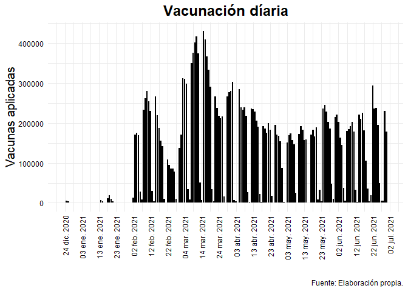

```
## # A tibble: 1 x 2
##   fecha      sum_cantidad
##   <date>            <dbl>
## 1 2021-03-15       430093
```

```
## # A tibble: 1 x 2
##   fecha      sum_cantidad
##   <date>            <dbl>
## 1 2021-01-30            1
```

```
##    Min. 1st Qu.  Median    Mean 3rd Qu.    Max.    NA's
##     1.0    16.0    66.0   207.6   193.0  8159.0   59647
```

```
## [1] "El promedio de vacunas por día es:  208"
```

```
## [1] "La mediana de vacunas por día es:  66"
```

```
## [1] "La moda de vacunas por día es:  1"
```

```
## [1] "Descripción de frecuencia por día mediante cuartil 1 es:  16"
```

```
## [1] "Descripción de frecuencia por día mediante cuartil 2 es:  66"
```

```
## [1] "Descripción de frecuencia por día mediante cuartil 3 es:  193"
```

```
## [1] "Varianza es:  199285.19"
```

```
## [1] "Desviación estándar es:  446.41"
```

```
## [1] "Rango entre cantidad de vacunados por día:  8158"
```

```
## [1] "La distancia entre el tercer y primer cuartil es:  177"
```

```
## [1] "Coeficiente de variación:  2.15"
```

Además, se realizaron otros análisis con estos datos.

> Análisis por dosis

```
## # A tibble: 3 x 2
##   dosis       sum_cantidad
##   <chr>              <dbl>
## 1 1 dosis         12199528
## 2 2 dosis         10270251
## 3 Unica dosis       414027
```

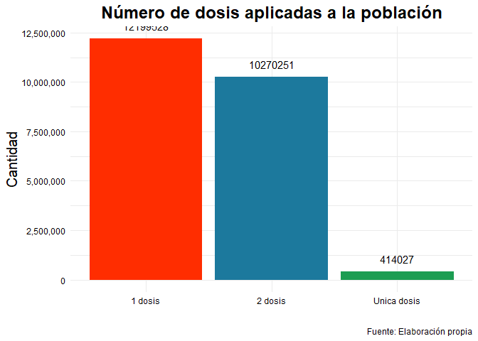

> Análisis por región

```
## # A tibble: 16 x 2
##    region                             sum_cantidad
##    <chr>                                     <dbl>
##  1 Aisén Gral. C. Ibáñez Campo              132777
##  2 Antofagasta                              758938
##  3 Arica y Parinacota                       265326
##  4 Atacama                                  357157
##  5 Bíobío                                  2011077
##  6 Coquimbo                                 977796
##  7 La Araucanía                            1211879
##  8 Libertador B. O'Higgins                 1263142
##  9 Los Lagos                               1062927
## 10 Los Ríos                                 491370
## 11 Magallanes y  La Antártica Chilena       239244
## 12 Maule                                   1411243
## 13 Metropolitana  Santiago                 9150686
## 14 Ñuble                                    672818
## 15 Tarapacá                                 393403
## 16 Valparaíso                              2484023
```

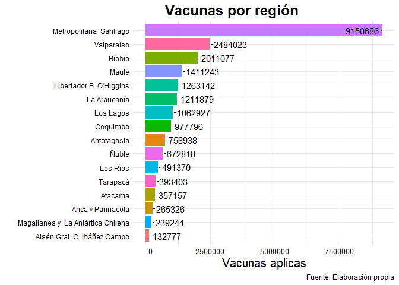

> Análisis por laboratorio

```
## # A tibble: 4 x 3
##   vacuna      sum_cantidad porcentaje_total
##   <chr>              <dbl>            <dbl>
## 1 AstraZeneca       368190             1.61
## 2 CanSino           414027             1.81
## 3 Pfizer           4617749            20.2
## 4 Sinovac         17483840            76.4
```

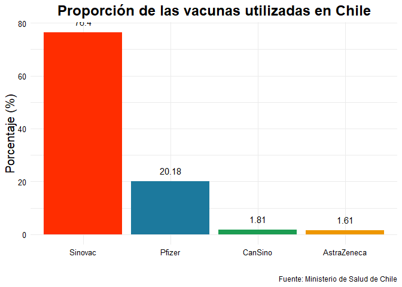

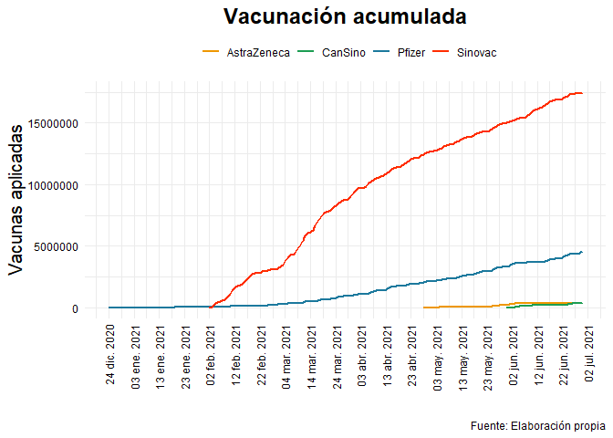